# Tutorial 00 - Operações Básicas

Victor G Alcantara

2023-04-26

## Operações básicas no R

O R é uma linguagem de programação. Como as outras (Python, Java, JS etc.), ele tem uma sintaxe específica. O diferencial do R é que é uma linguagem voltada para a estatística, o que atrai a comunidade acadêmica.

Caso queria consultar materiais mais elaborados, recomendo:

- Livro introdutório [R for data science](https://r4ds.had.co.nz/index.html)
- [Tutorial Leonardo Barone no GitHub](https://github.com/leobarone/cebrap_lab_programacao_r)

Neste tutorial, veremos o básico das operações em R.

## Parte I - Operações elementares

O R é, como as outras linguagens, uma grande calculadora. O principal fluxo de trabalho com dados é com *armazenamento* e *manuseio*.

É fundamental entender a sintaxe e funcionamento do R, pois a base serve para a programação de funções mais complexas. Tudo o que vamos ver de importação, manuseio e visualização de dados é programado com as operações básicas.

Sintaxe básica

Usamos “#” para comentar na linha do código. Ou seja, indicar que a linha é só um comentário e não deve ser computada.

```r
# Este é um comentário
```

Usamos aspas para indicar texto. Qualquer caractere sem aspas o R vai entender como objeto

```r
"Este é um texto e deve ser escrito entre aspas"
```

```
## [1] "Este é um texto e deve ser escrito entre aspas"
```

Qualquer erro, o R não computa e retorna uma msg de erro padrão.

```r
# Tente rodar a palavra teste sem aspas. Tire o comando do comentário

# teste
```

Note: como não definimos nada no objeto “teste”, logo ele retorna um erro indicando que não encontrou o objeto na memória.

O R é nosso amigão e muitas vezes, quando notar que pode ter algo errado, vai nos avisar com *Warning*

### Armazenamento

As informações podem ser armazenadas na memória do computador em *objetos*.

A atribuição de informação a um objeto é feita com a setinha (<-) ou o igual (=)

Veja o exemplo:

```r
objeto <- "Este é um objeto"

idade <- 12
```

caso queira guardar mais de uma informação, é preciso colocar entre parênteses e concatenar com “c”

```r
idade <- c(10,11,12,13,14,15)

# Alternativamente podemos escrever

idade <- c(10:15)
```

### Manuseio

Podemos fazer cálculos com R, veja:

```r
# 1. R como calculadora ----

2+3      # soma
```

```
## [1] 5
```

```r
2*3      # multiplicação
```

```
## [1] 6
```

```r
2^2      # potência
```

```
## [1] 4
```

```r
sqrt(16) # raíz quadrada / square roots
```

```
## [1] 4
```

```r
16^(1/2)
```

```
## [1] 4
```

```r
exp(1)   # exponencial
```

```
## [1] 2.718282
```

```r
log(10)  # logarítmo
```

```
## [1] 2.302585
```

```r
log2(16)
```

```
## [1] 4
```

```r
# No python não tem isso!
pi-2
```

```
## [1] 1.141593
```

Podemos também fazer cálculos com objetos, veja:

```r
# 2. Objetos ----

x <- 2
x+3
```

```
## [1] 5
```

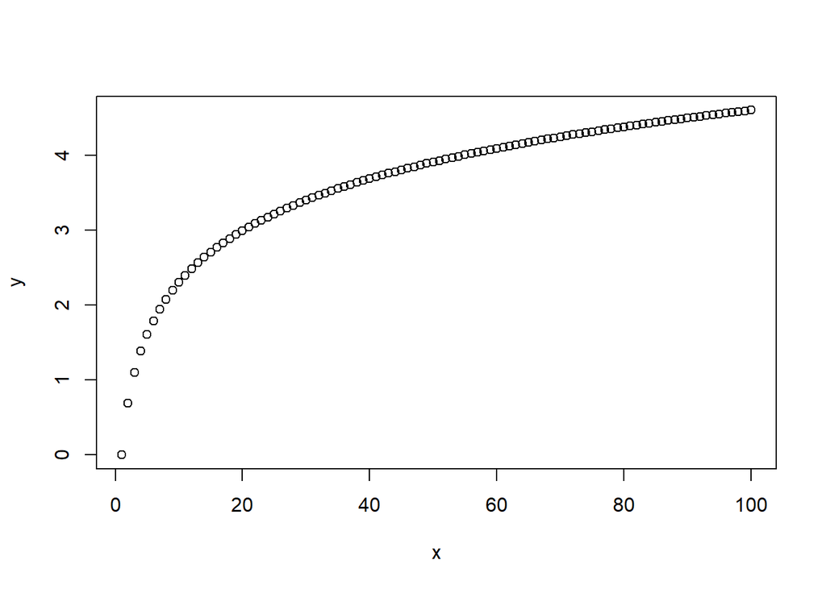

```r
x <- 1:100
y <- log(1:100)

plot(x,y)
```

Além dos cálculos, podemos também fazer operações lógicas (Verdadeiro/Falso)

```r
# 3. Operações lógicas ----
# São operações em testamos uma sentença tendo como resultado:
# TRUE (T) ou FALSE (F)

2 >  2  # MAIOR QUE
```

```
## [1] FALSE
```

```r
2 < 2   # MENOR QUE
```

```
## [1] FALSE
```

```r
2 == 3  # IGUALDADE
```

```
## [1] FALSE
```

```r
2 >= 2 # MAIOR OU IGUAL
```

```
## [1] TRUE
```

```r
# Por quê igualdade são dois sinais?
# R: Porque apenas um significa atribuição de valor. Igual a setinha.

x = 1:10
x <- 1:10

"eu" == "todo mundo" # Igualdade
```

```
## [1] FALSE
```

```r
"eu" == "eu"
```

```
## [1] TRUE
```

```r
"eu" != "vc"         # Diferença
```

```
## [1] TRUE
```

```r
# Teste em grupo
"eu" %in% c("vc","todo mundo") # Generalização - se contém
```

```
## [1] FALSE
```

```r
# Nota importante: "!" opera como um sinal de negação/diferença

!("eu" %in% c("vc","todo mundo"))
```

```
## [1] TRUE
```

Podemos também estabelecer relações de “E” e “OU”

```r
# 4. Relações "OU" e "E" ----
# "|" para "OU"
2 > 2 | 2 == 2
```

```
## [1] TRUE
```

```r
2 > 2 | 2 < 2
```

```
## [1] FALSE
```

```r
# "&" para "E"
2 > 2 & 2 == 2
```

```
## [1] FALSE
```

```r
2 > 1 & 2 == 2
```

```
## [1] TRUE
```

Aqui vou acelerar o passo-a-passo para colocarmos tudo em prática.

Com as operações básicas, podemos programar funções. As funções são algoritmos que fazem um determinado procedimento. São caixas pretas onde colocamos um input e recebemos um output.

A lógica é essa: Input -> |FUNÇÃO| -> output

Escrevemos o nome da função seguido de parênteses. Dentro dos parênteses inserimos os argumentos necessários, veja:

*função*(atributo1 = isso, atributo2 = aquilo)

Vamos ver um exemplo.

```r
# 7. Funções ----
# são operações já programadas
# (input-processo-output)
# nome_da_função(argumentos)

# Exemplo de funções
# argumentos = input

# A função ifelse recebe como argumento principal um teste lógico, e retorna
# o que quisermos se a condição é verdadeira ou falsa (input em yes/no)

# 1 é maior do que 3? Se sim, retorne "Verdade", se não, "Mentira"
ifelse(test = 1>3,yes = "Verdade",no ="Mentira")
```

```
## [1] "Mentira"
```

```r
ifelse # Veja como essa função está programada
```

```
## function (test, yes, no)
## {
##     if (is.atomic(test)) {
##         if (typeof(test) != "logical")
##             storage.mode(test) <- "logical"
##         if (length(test) == 1 && is.null(attributes(test))) {
##             if (is.na(test))
##                 return(NA)
##             else if (test) {
##                 if (length(yes) == 1) {
##                   yat <- attributes(yes)
##                   if (is.null(yat) || (is.function(yes) && identical(names(yat),
##                     "srcref")))
##                     return(yes)
##                 }
##             }
##             else if (length(no) == 1) {
##                 nat <- attributes(no)
##                 if (is.null(nat) || (is.function(no) && identical(names(nat),
##                   "srcref")))
##                   return(no)
##             }
##         }
##     }
##     else test <- if (isS4(test))
##         methods::as(test, "logical")
##     else as.logical(test)
##     ans <- test
##     len <- length(ans)
##     ypos <- which(test)
##     npos <- which(!test)
##     if (length(ypos) > 0L)
##         ans[ypos] <- rep(yes, length.out = len)[ypos]
##     if (length(npos) > 0L)
##         ans[npos] <- rep(no, length.out = len)[npos]
##     ans
## }
## <bytecode: 0x0000015ed4175828>
## <environment: namespace:base>
```

Loucura né? Deixa pro pessoal da computação essa parte. O importante é entender o que a função faz para utilizá-la.

Os *pacotes* são conjuntos de funções programadas. Temos uma infinidade de pacotes disponíveis com funções diferentes. No curso, trabalharemos com pacotes tradicionais de análise de dados.

São eles:

*rio*: R Input Output, para importação de dados

*tidyverse*: para manuseio dos dados

*ggplot2*: Grammar of Graphics, para visualização dos dados.

Quando baixamos o R, temos apenas o programa e nenhum pacote adicional.

Portanto, precisamos instalar os pacotes que precisamos. A função *install.packages* faz o download do pacote no repositório do R e instala na nossa máquina. Depois de instalado, temos que carregar o pacote na memória toda vez que abrimos o R para trabalhar. Para carregar o pacote, usamos a função *library*.

Em geral, começamos nosso código com a identificação da autoria, algumas informações do trabalho e uma parte dedicada ao *setup*, com a instalação e carregamento dos pacotes necessários.

```r
# 8. Pacotes ----
# são conj. de funções
# devem ser instalados    : install.packages()
# deve carregar na memória: library()

# Tire o "#" se necessário instalar

#install.packages("tidyverse") # Principal biblioteca de funções para manuseio
#install.packages("rio") # Biblioteca para importação dos dados

# Carregando os pacotes ou "pegando na biblioteca do computador"
library(tidyverse)
library(rio)
```

Antes de finalizarmos, precisamos ver algumas funções básicas de conexão entre o R e nosso computador.

Lembre-se: quando estamos trabalhando no R, sempre temos uma pasta de referência, que chamamos diretório de trabalho ( *Working Directory* - wd), onde o R busca e salva arquivos.

```r
# 9. Navegação no computador ----
# wd : Working Directory = Diretório/pasta de trabalho

# Get wd
getwd() # Em qual diretório/pasta estou trabalhando?
```

```
## [1] "G:/Meu Drive/00 GitHub/R-Introduction/A01 - Intro/01 codes"
```

```r
# Directory
dir()   # o que tem nesse diretório/pasta?
```

```
## [1] "A01 - Intro - basic R.R"
## [2] "A01 - Intro - slides.Rmd"
## [3] "Tutorial-00---operações-básicas.html"
## [4] "Tutorial-00---operações-básicas.Rmd"
## [5] "Tutorial-00---operações-básicas_files"
## [6] "Tutorial 00 - operações básicas.Rmd"
## [7] "tutorial_01.html"
## [8] "tutorial_01.Rmd"
```

```r
# Set wd
# setwd() # Configure o diretório de trabalho

# dir.create("minha pasta") # Crie uma pasta com este nome
```

Vamos pular mais alguns passos para irmos direto ao ponto.

Já podemos abrir uma base de dados.

Em geral, as bases são estruturadas em CSV (Comma Separated Values), que são valores separados por vírgula.

Recomendo que você abra um arquivo Wordpad e escreva o seu próprio dado, antes de importarmos outros.

Abra um Wordpad e cole o seguinte:

nome,idade,sexo,raca,renda “Laura”,33,“F”,“branca”,3300 “Gabriel”,17,“M”,“preta”,1220 “Alexandra”,26,“F”,“parda”,1800 “Fernando”,45,“M”,“branca”,13000

Quando for salvar o documento, salve como: “meus_dados.csv”

Note que se você não especificar “.CSV”, o arquivo será salvo como “.TXT”

Quando importarmos, o R vai entender que cada linha corresponde a um caso e o primeiro será o nome das variáveis. Da seguinte forma:

[output not shown]

Agora defina o endereço da pasta onde está o arquivo com os dados e importe para o R.

Obs.: se estiver usando windows, as barras devem ser invertidas. O R foi programado para Linux, pois faz parte do projeto GNU, e as barras que separam o endereço no sistema é “/”

Deve inverter as barras para ficar assim: G:/Meu Drive/00 GitHub/R-Introduction/A01 - Intro/00 data

```r
setwd("G:/Meu Drive/00 GitHub/R-Introduction/A01 - Intro/00 data")

meus_dados <- import("meus_dados.csv")

meus_dados
```

```
##        nome idade sexo   raca renda
## 1     Laura    33    F branca  3300
## 2   Gabriel    17    M  preta  1220
## 3 Alexandra    26    F  parda  1800
## 4  Fernando    45    M branca 13000
```

Vamos parar aqui para praticar essa parte básica (que é MUITO importante)

Tente fazer o tutorial 01 do data.frame, nele tem mais explicações sobre como lidar com bases de dados estruturadas.